# When Children Bear the Burden

## 📊 Countries Carrying the Heaviest Burden

In 2023, the most recent year of UNICEF data, approximately **918,000 adolescents aged 10–19 died worldwide** — a 31.5% decline from the 1,340,000 recorded in 1990. Progress is real, but the remaining burden is concentrated in a small number of countries.

The bar chart below ranks the **15 countries with the highest adolescent death counts in 2023**. These 15 nations together account for roughly **60% of all global adolescent deaths** despite representing a fraction of the world’s countries.

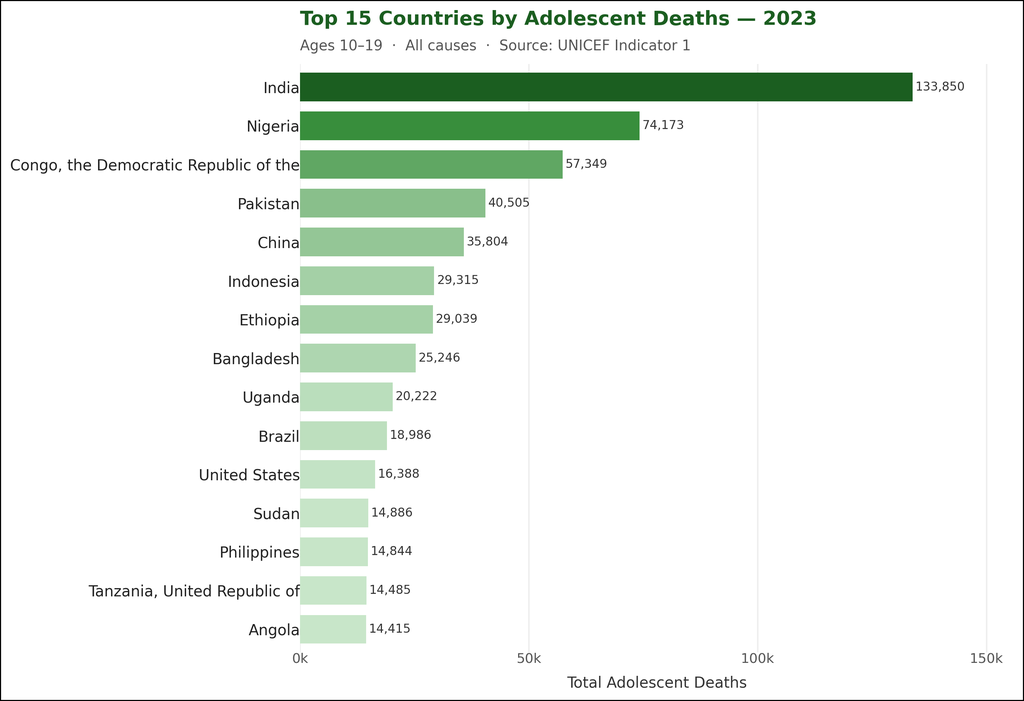

Figure 2: Top 15 countries by total adolescent deaths (ages 10–19), 2023. Counts are across all causes. Labels show exact death counts.

```python
(
    ggplot(ind1_top15,
           aes(x="reorder(country, deaths)", y="deaths", fill="deaths"))
    + geom_col(width=0.74, show_legend=False)
    + geom_text(
        aes(label="deaths"),
        format_string="{:,.0f}",
        ha="left", size=8, color="#333333", nudge_y=600
    )
    + coord_flip()
    + scale_fill_gradientn(
        colors=["#c8e6c9", "#388e3c", "#1b5e20"]
    )
    + scale_y_continuous(
        labels=lambda lst: [f"{int(x / 1000)}k" for x in lst],
        expand=(0, 0, 0.16, 0)
    )
    + theme_minimal()
    + theme(
        axis_text_y=element_text(size=10, color="#222222"),
        axis_text_x=element_text(size=9,  color="#555555"),
        axis_title_x=element_text(size=10, color="#333333"),
        plot_title=element_text(size=13, weight="bold", color="#1b5e20"),
        plot_subtitle=element_text(size=9.5, color="#555555"),
        panel_grid_major_y=element_blank(),
        panel_grid_minor_x=element_blank(),
        panel_grid_major_x=element_line(color="#eeeeee"),
        plot_background=element_rect(fill="white"),
        figure_size=(9.5, 6.5)
    )
    + labs(
        title=f"Top 15 Countries by Adolescent Deaths — {latest_year}",
        subtitle="Ages 10–19  ·  All causes  ·  Source: UNICEF Indicator 1",
        x="",
        y="Total Adolescent Deaths"
    )
)
```

**📌 Key insight:** **India (133,850)** and **Nigeria (74,173)** together account for nearly **23% of all global adolescent deaths** in 2023. Population size is a contributing factor, but it is not the whole story. The **Democratic Republic of Congo (57,349)**, **Pakistan (40,505)**, and **Ethiopia (29,039)** all rank far higher than their population share would predict, reflecting the compounding effects of poverty, conflict, and limited healthcare access. Notably, the **United States (16,388)** appears in the top 15 — driven primarily by traffic accidents, gun violence, and drug overdoses — a reminder that high national income does not eliminate adolescent mortality risk.

## 💹 Wealth, Health, and Diminishing Returns

A foundational question in global health is how much of the variation in child survival outcomes can be explained simply by a country’s **economic output**. The scatterplot below plots **GDP per capita** (constant 2015 USD, log-scaled) against **life expectancy at birth** for 208 countries, using the most recent available data from the UNICEF metadata file.

The Pearson correlation is **r = 0.61** — moderate to strong — confirming that economic development is one of the most powerful drivers of health outcomes. But the **log scale on the x-axis** tells an equally important story: returns are largest at the bottom of the income spectrum and diminish sharply as countries grow wealthier.

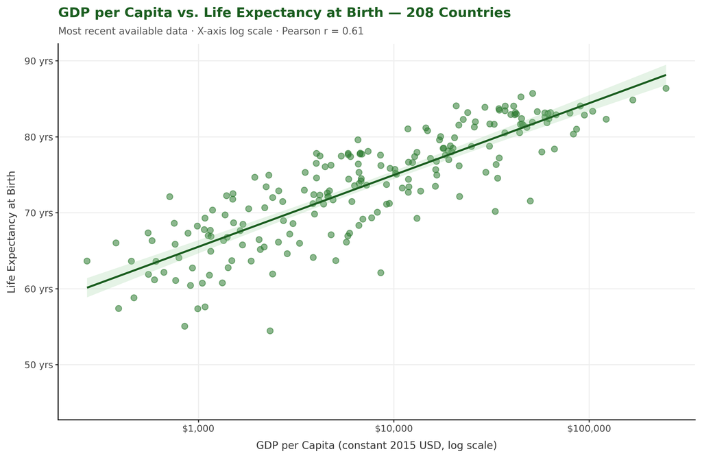

Figure 3: GDP per capita (constant 2015 USD, log scale) vs. life expectancy at birth. Most recent available data per country (n = 208). Green line = OLS linear regression with 95% confidence band (r = 0.61).

```python
(
    ggplot(scatter_df, aes(x="gdp", y="life_exp"))
    + geom_point(color="#2e7d32", alpha=0.55, size=2.8)
    + geom_smooth(method="lm", color="#1b5e20", fill="#a5d6a7", alpha=0.28, size=1.1)
    + scale_x_log10(
        labels=lambda lst: [f"${int(x):,}" for x in lst]
    )
    + scale_y_continuous(
        limits=[45, 90],
        labels=lambda lst: [f"{int(x)} yrs" for x in lst]
    )
    + theme_classic()
    + theme(
        plot_title=element_text(size=13, weight="bold", color="#1b5e20"),
        plot_subtitle=element_text(size=9.5, color="#555555"),
        axis_text=element_text(size=9, color="#444444"),
        axis_title=element_text(size=10, color="#333333"),
        panel_grid_major=element_line(color="#eeeeee"),
        plot_background=element_rect(fill="white"),
        figure_size=(9.5, 6.2)
    )
    + labs(
        title="GDP per Capita vs. Life Expectancy at Birth — 208 Countries",
        subtitle="Most recent available data · X-axis log scale · Pearson r = 0.61",
        x="GDP per Capita (constant 2015 USD, log scale)",
        y="Life Expectancy at Birth"
    )
)
```

**📌 Key insight:** The log-linear shape of the relationship is the critical finding here. A country moving from **$500 to $5,000** per capita gains far more life expectancy than one moving from **$30,000 to $60,000**. Countries in the **lower-left cluster** — concentrated in sub-Saharan Africa — combine GDPs below $2,000 with life expectancies between 55 and 65 years. High-income nations in the **upper-right** plateau above 80 years. The scatter of points around the regression line also confirms that **governance, policy, and public health investment** allow some countries to dramatically outperform their income level — and others to underperform.

## 📈 Three Decades of Adolescent Deaths, by Sex

The time-series below traces global adolescent deaths separately for **male and female adolescents** from 1990 to 2023. It is the most direct window into whether, and how quickly, the world is making progress on one of its most preventable human costs.

**The long decline.** Both male and female deaths fell substantially between 1990 and 2015, driven by expanded vaccination, the scale-up of antiretroviral therapy, improved obstetric care, and targeted malaria interventions aligned with the Millennium Development Goals.

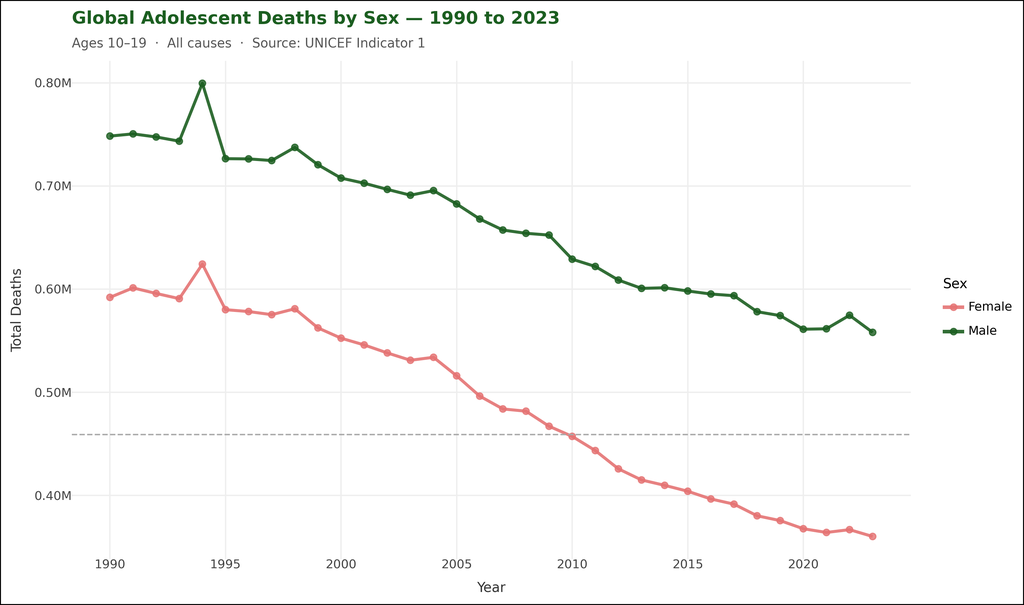

Figure 4: Global adolescent deaths (ages 10–19) by sex, 1990–2023. Each point is the globally aggregated annual sum. The dashed line marks the 2023 midpoint between male and female totals.

```python
midpoint_2023 = ind1_sex[ind1_sex["year"] == 2023]["total_deaths"].mean()

(
    ggplot(ind1_sex, aes(x="year", y="total_deaths", color="sex", group="sex"))
    + geom_line(size=1.25, alpha=0.9)
    + geom_point(size=2.2, alpha=0.8)
    + geom_hline(
        yintercept=midpoint_2023,
        linetype="dashed", color="#aaaaaa", size=0.6
    )
    + scale_color_manual(
        values={"Female": "#e57373", "Male": "#1b5e20"},
        name="Sex"
    )
    + scale_y_continuous(
        labels=lambda lst: [f"{x / 1_000_000:.2f}M" for x in lst]
    )
    + scale_x_continuous(
        breaks=list(range(1990, 2025, 5)),
        labels=lambda lst: [str(int(x)) for x in lst]
    )
    + theme_minimal()
    + theme(
        plot_title=element_text(size=13, weight="bold", color="#1b5e20"),
        plot_subtitle=element_text(size=9.5, color="#555555"),
        axis_text=element_text(size=9, color="#444444"),
        axis_title=element_text(size=10, color="#333333"),
        legend_title=element_text(size=10),
        legend_text=element_text(size=9),
        panel_grid_minor=element_blank(),
        panel_grid_major=element_line(color="#eeeeee"),
        plot_background=element_rect(fill="white"),
        figure_size=(10.5, 6.2)
    )
    + labs(
        title="Global Adolescent Deaths by Sex — 1990 to 2023",
        subtitle="Ages 10–19  ·  All causes  ·  Source: UNICEF Indicator 1",
        x="Year",
        y="Total Deaths"
    )
)
```

## 🔍 Key Findings

**📉 Progress is real, but incomplete.** Global adolescent deaths fell by **31.5%** between 1990 and 2023 — from 1.34 million to 918,000. Yet 918,000 preventable deaths per year still amounts to roughly **2,500 young people every single day**, the overwhelming majority in low- and lower-middle-income countries.

**🦟 Malaria diagnostics remain critically underfunded.** Only **56 countries** report malaria testing data to UNICEF. Across those countries, the average rate of diagnostic testing in febrile children under five is just **24.4%**. Sudan leads at 57.4%; Myanmar records just 3%. The majority of children showing malaria symptoms in endemic regions are never confirmed.

**💰 Economic development saves lives, with diminishing returns.** The GDP–life expectancy correlation across 208 countries is **r = 0.61**. The log-linear relationship means the health returns to economic growth are highest at the bottom of the income spectrum, making the case for prioritising development aid in the lowest-income, highest-burden contexts.

## 📂 Data Sources

The analysis in this report is based exclusively on publicly available data from UNICEF and the World Bank, accessed via the UNICEF Data Warehouse in 2025:

| Dataset | Description | Coverage | Source |
| --- | --- | --- | --- |
| **unicef_indicator_1.csv** | Deaths aged 10 to 19, by sex and country, all causes | 199 countries, 1990–2023 | [UNICEF Data Warehouse](https://data.unicef.org/resources/data_explorer/unicef_f/?ag=UNICEF&df=GLOBAL_DATAFLOW&ver=1.0&dq=.CME_TMM0T19..&startPeriod=1990&endPeriod=2023) |
| **unicef_indicator_2.csv** | Malaria diagnostics — % febrile children under 5 tested | 56 countries, 2009–2024 | [UNICEF Data Warehouse](https://data.unicef.org/topic/child-health/malaria/) |
| **unicef_metadata.csv** | GDP per capita, life expectancy, population and macro indicators | 211 countries, 1960–2024 | [World Bank Open Data via UNICEF](https://data.worldbank.org/indicator) |

All files were provided as part of **BAA1030 Module, Assignment 2**, Dublin City University (2025–2026). No external APIs, web scraping, or additional datasets were used in this analysis.